# imcarlyy_OriginalHomeworkCode_03

## FIFTH EXERCISE

dim(survivors)

### 5.1 Samplying 30 zombie survivors (without replacement) from this population

```r
set.seed(123)
sampled_zombie_survivors <- survivors[sample(1:nrow(survivors), 30, replace = FALSE), ]
```

### 5.2 Calculate the mean and sample standard deviation for each variable.

```r
# Sample means:
mean_height <- mean(sampled_zombie_survivors$height)
mean_weight <- mean(sampled_zombie_survivors$weight)
mean_age <- mean(sampled_zombie_survivors$age)
mean_zombies_killed <- mean(sampled_zombie_survivors$zombies_killed)
mean_education <- mean(sampled_zombie_survivors$years_of_education)

# Sample SDs:
sd_height <- sd(sampled_zombie_survivors$height)
sd_weight <- sd(sampled_zombie_survivors$weight)
sd_age <- sd(sampled_zombie_survivors$age)
sd_zombies_killed <- sd(sampled_zombie_survivors$zombies_killed)
sd_education <- sd(sampled_zombie_survivors$years_of_education)
```

### 5.3 Calculating the sample size and estimating the standard error for each variable.

```r
#Calculating the sample size
sample_size <- nrow(sampled_zombie_survivors)

#Estimate the standard error for each variable.
se_height <- sd_height / sqrt(sample_size)
se_weight <- sd_weight / sqrt(sample_size)
se_age <- sd_age / sqrt(sample_size)
se_zombies_killed <- sd_zombies_killed / sqrt(sample_size)
se_education <- sd_education / sqrt(sample_size)
```

> It might be good to display all of these results

### 5.4 Construct 95% Confidence Intervals.

```r
# I have a normal variables on height and age, so the following distributions will be used:

  #Confidence interval for normal distribution (height and age)
Confidence_interval_height <- c(mean_height - 1.96 * se_height, mean_height + 1.96 * se_height)
Confidence_interval_age <- c(mean_age - 1.96 * se_age, mean_age + 1.96 * se_age)


  #Confidence intervals for my non-normal variables
t_value <- qt(0.975, df = sample_size - 1)

  #Confidence intervals using t-distribution in my non-normal distribution (weight, zombies killed and years of education)

Confidence_interval_weight <- c(mean_weight - t_value * se_weight, mean_weight + t_value * se_weight)

Confidence_interval_zombies_killed <- c(mean_zombies_killed - t_value * se_zombies_killed,
                                        mean_zombies_killed + t_value * se_zombies_killed)

Confidence_interval_education <- c(mean_education - t_value * se_education,
                                   mean_education + t_value * se_education)

print(paste("95% Confidence Interval for Height: [", Confidence_interval_height[1], ",", Confidence_interval_height[2], "]"))
```

```
## [1] "95% Confidence Interval for Height: [ 66.3760052172455 , 68.9027736640878 ]"
```

```r
print(paste("95% Confidence Interval for Weight: [", Confidence_interval_weight[1], ",", Confidence_interval_weight[2], "]"))
```

```
## [1] "95% Confidence Interval for Weight: [ 140.94305669379 , 151.877094232877 ]"
```

```r
print(paste("95% Confidence Interval for Age: [", Confidence_interval_age[1], ",", Confidence_interval_age[2], "]"))
```

```
## [1] "95% Confidence Interval for Age: [ 18.4146444280814 , 20.2438888339186 ]"
```

```r
print(paste("95% Confidence Interval for Zombies Killed: [", Confidence_interval_zombies_killed[1], ",", Confidence_interval_zombies_killed[2], "]"))
```

```
## [1] "95% Confidence Interval for Zombies Killed: [ 1.89984446616991 , 3.16682220049676 ]"
```

```r
print(paste("95% Confidence Interval for Years of Education: [", Confidence_interval_education[1], ",", Confidence_interval_education[2], "]"))
```

```
## [1] "95% Confidence Interval for Years of Education: [ 2.56874686882035 , 3.63125313117965 ]"
```

## SIXTH EXERCISE

### 6.1 Now draw 99 more random samples of 30 zombie apocalypse survivors, and calculate the mean for each variable for each of these samples. Together with the first sample you drew, you now have a set of 100 means for each variable (each based on 30 observations), which constitutes a sampling distribution for each variable.

```r
#I will begin calculating my sampling Distributions
set.seed(123)

n_samples <- 100  # Number of samples I'll draw
sample_size <- 30  # Sample size of 30

#Now, I'll use the following function to calculate the means of variables from a random sample
sample_means <- function(data, sample_size) {
  sampled_data <- data[sample(1:nrow(data), sample_size, replace = FALSE), ]

#Returning the means of the variable
c(
    mean_height = mean(sampled_data$height),
    mean_weight = mean(sampled_data$weight),
    mean_age = mean(sampled_data$age),
    mean_zombies_killed = mean(sampled_data$zombies_killed),
    mean_education = mean(sampled_data$years_of_education)
  )
}

#Now, I'm replicating to repeat my sampling process 100 times
samples_matrix <- replicate(n_samples, sample_means(survivors, sample_size))

#Now, I'm converting the matrix into a data frame
samples_df <- data.frame(t(samples_matrix))
colnames(samples_df) <- c("mean_height", "mean_weight", "mean_age", "mean_zombies_killed", "mean_education")
```

```r
# Calculate mean and standard deviation for each variable's sampling distribution
sampling_distribution_stats <- data.frame(
  mean_height = mean(samples_df$mean_height),
  sd_height = sd(samples_df$mean_height),
  mean_weight = mean(samples_df$mean_weight),
  sd_weight = sd(samples_df$mean_weight),
  mean_age = mean(samples_df$mean_age),
  sd_age = sd(samples_df$mean_age),
  mean_zombies_killed = mean(samples_df$mean_zombies_killed),
  sd_zombies_killed = sd(samples_df$mean_zombies_killed),
  mean_education = mean(samples_df$mean_education),
  sd_education = sd(samples_df$mean_education)
)

print(sampling_distribution_stats)
```

```
##   mean_height sd_height mean_weight sd_weight mean_age    sd_age
## 1    67.69484 0.6765653    143.9472  2.999171  20.0724 0.4878208
##   mean_zombies_killed sd_zombies_killed mean_education sd_education
## 1            2.958333         0.3425125          3.019    0.3160238
```

> I would create a function for this in order to avoid a repetitive block of code.

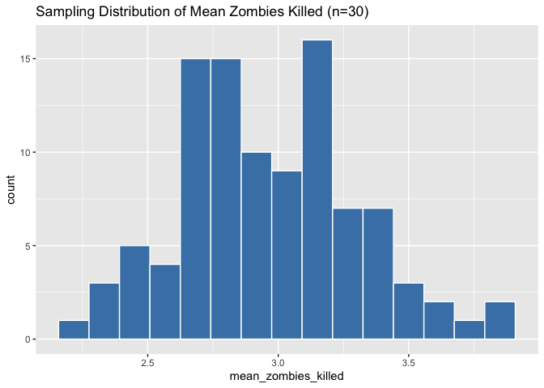

```r
#Here, I will be visualizing the Sampling Distribution for Mean Zombies Killed
ggplot(samples_df, aes(x = mean_zombies_killed)) +
  geom_histogram(bins = 15, fill = "steelblue", color = "white") +
  labs(title = "Sampling Distribution of Mean Zombies Killed (n=30)")
```

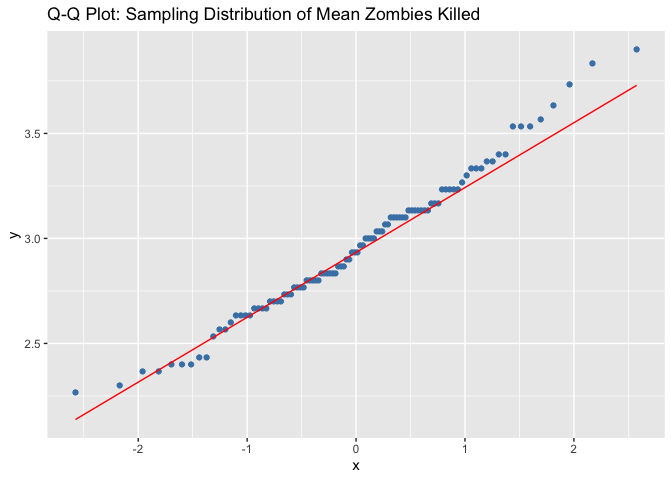

```r
ggplot(samples_df, aes(sample = mean_zombies_killed)) +
  stat_qq(color = "steelblue") +
  stat_qq_line(color = "red") +
  labs(title = "Q-Q Plot: Sampling Distribution of Mean Zombies Killed")
```

> I like the color choices here!

## CHALLENGES FACED:

1. One of the biggest challenges that I had here was on my second exercise, making my grid. I kept trying to use the patchwork package, and giving R the instruction of displaying a 3x2 grid. However, it became too complicated. I overcame this challenge after I learned about another package (gridExtra) that I could use, and that could follow my command without forcing me to create another empty plot. After noticing that this package was easier to manage for my data, I switched and it all worked!
2. I kept making a lot of typos, and that made my homework even longer than expected. I am considering using less text/words for the names I assign to certain factors/variables because sometimes those can turn out too long, and make everything even more confusing and harder to keep track.
3. For some reason, in this homework I kept getting an error saying that I didn’t have my CRAN mirror in R/my project? It was very weird and although I understand what its purpose is a little more, I never got to figure out why I suddently started having that problem. I did some research and found out that I needed to display it in my project (choosing the URL that works in the US), and that solved it all.
4. It was also hard to knitt my project using the theme that Prof. Schmitt mentioned in the homework instructions. I took at least 2 more hours for that (when I usually take no more than 15 min), and then after a lot of research and trial/error, I found out that sometimes such themes only work on older R versions. Therefore, that in order to have it activate in my laptop, I needed to “degrade” my R Studio version. However, it was not 100% guaranteed that my problem was going to be solved. I chose to use another theme considering this situation.
5. In exercise 4, when doing the Q-Q Plot, I had a lot of issues too because my package wasn’t running properly. I found out that I was running the function qqplot, instead of the one that I HAD to use with the (car) package: qqPlot. I also kept forgetting to run the “library(car)” package first , which lead me to (again), spend a huge amount of time trying to figure out what to do to fix it.

> This all looks good! I like a lot of your plotting and formatting decisions, and your annotation is excellent. There were a few areas where creating a function could shorten the code a bit and make it less repetitive, but I also know first-hand that that can quickly spiral out of control and end up taking way longer than expected. Overall, though, I don’t see any major issues!